# The Case for a Modern Collaborative Data Science Platform

## BANK AUG Presentation

- Gilles Demaneuf (8 years of data science, 100+ employee San Francisco/Hong Kong AI startup and investment)
- William Remor (4 years in decision systems and microsoft based applications)

# How should we do data science?

## We should be able to do AGILE data science:

### 1. Quick exploration of data

### 2. Quick prototyping of models using whatever appropriate language or package

### 3. Clear linear progression from exploration to hypotheses, tests, predictions

### 4. Ability to easily share code, notes and results for peer review and enrichment from team. No Powerpoint, Excel or complex project to share! Share everything online.

### 5. Ability to pull together and share comon code

### 6. Easy transition from prototype to production

# How should we do data science?

## We should make data fun, rewarding and easy to teach

### 1. Fun -> use the right tools from large popular toolboxes

### 2. Productive -> solve real problems with the best tools, move fast

### 3. Rewarding -> aquire valued skills in the data science world

### 4. Easy to teach -> use simple collaborative tools, which encapsulate code, notes, results, graphs in one reproducable whole

# How should we do data science?

## We should take a low risk strategic direction

### 1. Stay open to technology -> don't buy the vendor snake-oil. Stay open and use what makes sense today and then tomorrow.

### 2. Be able to scale -> use a solution to can scale from a few megabites of data to 100s of GB or more through links to Big Data solutions

# OK, so what are people using to do Modern Collaborative Data Science?

- **Microsoft Azure:**
  - Python/R on Jupyter Notebooks https://notebooks.azure.com/
- **IBM:**
  - Python, R, Scala on Jupyter Notebook, Big Data support with Spark, https://datascience.ibm.com/desktop
- **Google, Spotify, Amazon, you name it:**
  - they are using amongst others Jupyter Notebook
- **Westpac, BNZ**:
  - Python/R with Notebooks getting there
- **Data driven science:**
  - Jupyter Notebook (with their own speciallized distributed architecture and libraries). Example: LIGO detector Open Science (Physics Nobel Prize 2017): https://losc.ligo.org/tutorials/, https://notebooks.azure.com/losc/libraries/tutorials/html/LOSC_Event_tutorial.ipynb
- **SAS:**
  - SAS is supported as one language in Jupyter Notebook (kernel on GitHub, part of SAS University Edition). https://anaconda.org/ijstokes/sas-and-jupyter-in-5-minutes/notebook

# So what is a Data Science Notebook?

Think of the good old laboratory notebook where you

- start by writing down some hypothesis
- design way to validate/invalidate it
- describe the quick experiments you follow including some dead-ends (so that anybody can reproduce or avoid them)
- take notes of the results
- fork into interesting sub-studies
- then reach your conclusion – with all quantitative data and illustrations to support it
- hand over the notebook to your colleagues for them to validate your work
- then 2 years later publish your prize-winning paper in a form that has little to do with the discovery process you actually followed!

**It is not the final paper you may publish, it is the FULL LINEAR JOURNEY you took to get to the results – a journey that you share with your collaborators so that they can validate it or improve it.**

### Do some standard initialisations:

```python
import matplotlib
import numpy as np
import matplotlib.pyplot as plt
import pandas as pd;
import seaborn as sns;

%matplotlib inline
```

### 1. Import data:

```python
sns.set()

# Load the example tips dataset
iris = sns.load_dataset("iris")
```

### 2. Quickly check data:

```python
iris.head(2)
```

[output not shown]

```python
iris.describe()
```

|  | sepal_length | sepal_width | petal_length | petal_width |
| --- | --- | --- | --- | --- |
| count | 150.000000 | 150.000000 | 150.000000 | 150.000000 |
| mean | 5.843333 | 3.057333 | 3.758000 | 1.199333 |
| std | 0.828066 | 0.435866 | 1.765298 | 0.762238 |
| min | 4.300000 | 2.000000 | 1.000000 | 0.100000 |
| 25% | 5.100000 | 2.800000 | 1.600000 | 0.300000 |
| 50% | 5.800000 | 3.000000 | 4.350000 | 1.300000 |
| 75% | 6.400000 | 3.300000 | 5.100000 | 1.800000 |
| max | 7.900000 | 4.400000 | 6.900000 | 2.500000 |

*Add your notes as you go through what you see:*

- We can see that..
- And that..
- May be we should check that..

### 3. Fit a linear model and graph data:

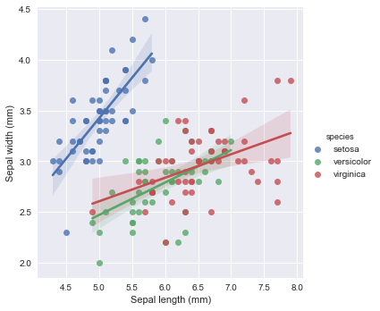

```python
# Plot tip as a function of toal bill across days
g = sns.lmplot(x="sepal_length", y="sepal_width", hue="species",
               truncate=True, size=5, data=iris)

# Use more informative axis labels than are provided by default
g.set_axis_labels("Sepal length (mm)", "Sepal width (mm)")
```

### 4. Keep going until you developped some insight / answered the question / built the model

### Then most important:

- Communicate your results by sharing the notebook directly, or sending it in html format, or as a presentation, or a PDF, etc.
- Archive your file and data (git, etc), or simply take a checkpoint of the Notebook

A data science notebook excels at:

- **Data cleaning / data exploration and getting maximum insights into data**
- **Quick (Agile) model prototyping** using whatever language (Python, R, SAS, Scala) and library does the job better
- **Sharing code and results easily**
- **Testing data/model** hypothesis in a clear/reviewable/sharable way – with everything in one place (code, text, graph, flow) and rerunable easily.
- **Training people..** Indeed the collaborative and re-runnable aspects of the notebooks are great tools to train great data scientists.
- **Scaling** through team libraries and support of the big data killers

This effectively amounts to 80% of the discovery/creative process we are involved with in the BANK.

See:

- https://www.datanami.com/2016/05/04/rise-data-science-notebooks
- https://svds.com/why-notebooks-are-super-charging-data-science/

# May be easier with some examples

Our Iris example: http://localhost:8889/notebooks/Work/Presentations/IrisExample.ipynb#

Here is a good example from a Kaggle competition: http://localhost:8889/notebooks/Work/REAL-PythonForWork/Jupyter/Notebooks/Examples/Python/kaggle-titanic/Titanic-Presentation.ipynb?#

# But what about Excel, SAS, Tableau?

None of the software solutions we have offers the advantages of data sciences notebooks

- **SAS EG is not a data science notebook:**
  - Complex iterative discovery process.
  - No linear story-telling, no easy mix of graph, text and code, no easy way of picking and mixing the appropriate languages for the task, inferior machine learning and graphing capabilities, no support for vector-based computation (instead row-by-row approach), limited debugging capacity, limited code tracking capacity, limited sharing capacity.
  - Because SAS is aware of these limitations, they are supporting Jupyter with the SAS kernel and are trying to move users to SAS Viya (\$\$\$\$) when they are still using old SAS stacks because of the existing cost and complexity. [A kernel is a language client interpreting commands and sending back results, be it data or graphs]

# But what about Excel, SAS, Tableau?

None of the software solutions we have offers the advantages of data sciences notebooks

- **Tableau is not a data science notebook:**
  - Very good at producing fixed dashboards (final story telling), but not at supporting and sharing a discovery process and being able to quickly test alternatives with all the analytical power you can wish.
  - Not good at doing heavy data handling and custom data transformations (but lets you drop into Python or R)
  - **Tableau basically does not really support the journey, but just the destination.**

# So what can it change for the BANK?

### Covers 80% of our creative process:

- Data insights
- Agile model prototyping
- Sharable journey used to test an hypothesis
- Proper review process
- Easy model documentation

Note that the final code may run on SAS or in SQL – these are production software solutions. What we are asking for is better support of the creative (and Agile) process that delivers the data insights/model solutions that may end up being coded elsewhere.

# Tell me more about Jupyter Notebook

**Not a language**, but a glue that communicates with language kernels to display code, notes and results in a scientific notebook

- Supports all the main languages of Data Science **Ju**lia, **Pyt**hon, **R**, SAS, Scala, Lua, etc
  - You can actually even mix languages in the same notebook: for instance use Python for convenience and precision, then a specific R package that you like amongst other data processing or modelling steps.
- Supports all the main databases through language specific interfaces
- Supports SAS code and SAS data sets
  - You can load up SAS data sets in Python for instance, or work directly with SAS language and kernel
  - See https://anaconda.org/ijstokes/sas-and-jupyter-in-5-minutes/notebook
- Easy versioning (checkpoints)
- Supports Big Data architectures if required (Cloud Computing (AWS, AZURE) and Spark/Hadoop)
- Supports some debugging, straighforward parallel processing (R/Python)
- Open, Proven: very active community (1mln shared notebooks on GitHub) and all the big players are using it as a basic tool for data science
- Part of the Jupyter project, linked to Berkeley Institute for Data Science: https://bids.berkeley.edu/research/project-jupyter
- Includes complementary solutions such as Jupyter Hub (corporate Jupyter server), Jupyter Lab (http://localhost:8890/lab, proper developper environment to facilitate the move from Notebook to production).
- This presentation is a Jupyter Notebook: http://localhost:8889/notebooks/Work/Presentations/DataScience.ipynb